# Data Science and Data Analytics

Getting started

Julian Amon, PhD

Charlotte Fresenius Privatuniversität

March 13, 2026

# Course design

## Welcome to Data Science and Data Analytics!

- This is **B-GV-12 Data Science and Data Analytics**.
- The goal of this course is to teach you…
  - about the nature and role of data science in a data-driven world.
  - about the data science workflow.
  - to use open-source software to analyse, visualize and model data from various sources.
  - about different machine learning algorithms.
  - to implement your own data science projects.
  - to communicate the results of your analyses effectively.
  - and much more…

## Lectures

- With a few exceptions, lectures will be held on **Fridays from 13:30 to 16:30**.
- Please regularly check your course schedule to not miss any lectures.
- Lectures will consist of theory and practice discussed with the help of **slides** as well as **live coding sessions**.
- You are highly encouraged to **actively participate**!
- Exercises to practice what you have learned will be provided (but not graded).

## Grading

- There will be **no** final exam in this course!
- Instead, grading will be based on **group projects**:
  - Teams of 4 - 5 students will initiate and design a small data science project autonomously.
  - Each group will:
    - identify a business case mimicking a real-world research problem and an accompanying available data set.
    - formulate research questions on the basis of the chosen data set.
    - perform analyses using the concepts and methods learned throughout this course.

## Grading

- Grading will therefore be based on the following components:
  - **Group project report** (5-10 pages per group member): **65 %**
  - **Group presentation** ($\leq$ 20 mins/group and $\geq$ 2 mins/group member): **25 %**
  - **Peer review: 10 %**
- In line with the usual grading scheme, grades will be given as follows:

| Percentage | Grade |
| --- | --- |
| 95 - 100 % | 1,0 |
| 90 - 94 % | 1,3 |
| 85 - 89 % | 1,7 |
| 80 - 84 % | 2,0 |
| 75 - 79 % | 2,3 |
| 70 - 74 % | 2,7 |

| Percentage | Grade |
| --- | --- |
| 65 - 69 % | 3,0 |
| 60 - 64 % | 3,3 |
| 55 - 59 % | 3,7 |
| 50 - 54 % | 4,0 |
| below 50 % | 5,0 |

## Grading: Group project

- The **structure** of the group project (reflected in report and presentation) should be something like this:
  - Introduction / Motivation and research question
  - Data (sources, description, statistics, visualizations, …)
  - Models and model evaluation
  - Results
  - Discussion and comments
- Aspects that will influence your grade will be: the originality of the question, understanding of the business case, data and methods, correctness of application, thoroughness of evaluation, creativity and quality of report and presentation (both verbal and visual)
- Deductions will be made for purely AI-generated contributions.

## Grading: Group project

**Choice of topic**: while you are completely free in your choice of topic in the group, here are some areas of suggestion:

- Finance / Economics / Marketing
- Text analysis
- Entertainment (in particular: movies and music)
- Social network analysis
- Social sciences

**Sources for data sets**: while you are again free also in your choice of data set, good places to get you started are:

- [Statistik Austria](https://www.statistik.at/services/tools/services/opendata)
- [Kaggle](https://www.kaggle.com/datasets)
- [UCI Machine learning repository](https://archive.ics.uci.edu/)
- [World bank](https://datacatalog.worldbank.org/home)
- [EU](https://data.europa.eu/en)
- …

**Caution**

When selecting a data set, make sure, you are **allowed** to use this data for the purposes of your project! When selecting from the sources given, this should generally be ensured.

## Grading: Peer review

- After final project presentations, each **individual** student will be asked to write a **peer review** of one of the other groups’ projects.
- Each student will be randomly assigned **two projects**, out of which **one** should be reviewed (based on their presentation only).
- Evaluation is based on the **quality of review** that you write, not on the feedback that your project receives.
- The review should be **max 250 words** answering the following questions:
  - Briefly describe the topic, research questions and the employed methods.
  - State and briefly explain two positive comments about the work.
  - State and briefly explain two improvement suggestions.

**Important**

In your peer review, focus on **content**, not on the formatting or quality of the slides, for instance.

## Schedule

**March**

**13th**: Getting started, Introduction to Data Science (DS)

**20th**: The essentials of R programming, The DS workflow – Part I: Import, Tidy and Transform

**April**

**10th/17th**: The DS workflow – Part II: Visualize

**24th**: The DS workflow – Part III: Model

**May**

**8th/18th/22nd/29th**: The DS workflow – Part III: Model

**June**

**1st**: The DS workflow – Part IV: Communicate

**12th**: Final presentations of the group projects

**Deadlines**

- **20th March**: organize in teams, send team members via e-mail
- **11th June**: Send presentations via e-mail
- **26th June**: Hand in group project reports and peer reviews

## Questions and contact

- Any questions?
- Contact:
  - Anytime via e-mail: julianamonphd@gmail.com

# Course toolkit

## Software – Excel? ❌

[figure not shown]

## Software – R ✅

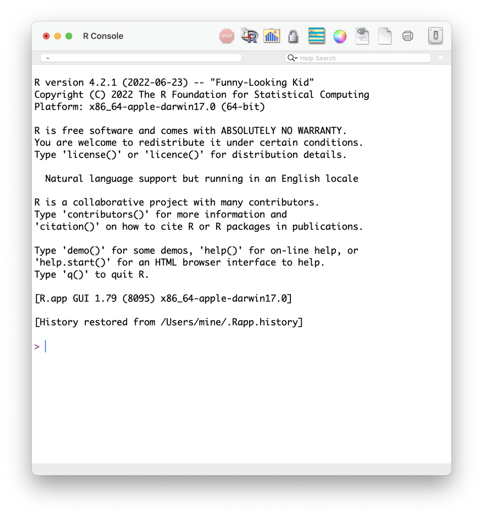

## Software – RStudio ✅

[figure not shown]

## Software – Quarto ✅

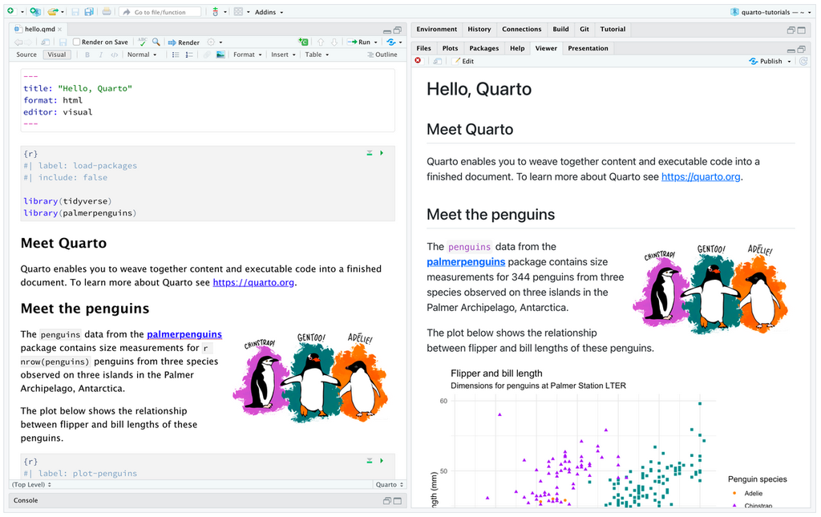

## Software

- Modern data science is unthinkable without **computer programming**: typically, either [Python](https://www.python.org/) or [R](https://www.r-project.org/) is used.
- For the purposes of this course, we will use:
  - The open-source statistical programming language [R](https://www.r-project.org/).
  - A bespoke integrated development environment (IDE) for R called [RStudio](https://posit.co/products/open-source/rstudio/).
  - An authoring framework for creating beautiful reports, presentations, web sites, etc., combining text, code, results and visualizations, called [Quarto](https://quarto.org/).
- Until next time, therefore please
  - either **install** R, RStudio and Quarto on your laptop (recommended) or
  - register for a free account at [Posit Cloud](https://posit.cloud/).

## Resources

- **Primarily**: slides and exercises provided
- However, for a deeper dive and additional materials, I recommend:

**For R programming**

[figure not shown]

[figure not shown]

Excellent courses from Harvard Professor Rafael Irizarry, available for free [here](https://www.edx.org/learn/r-programming/harvard-university-data-science-r-basics) and [here](https://www.edx.org/learn/data-visualization/harvard-university-data-science-visualization).

**For machine learning**

[figure not shown]

Excellent book, available for free [here](https://www.statlearning.com/).

## Resources – How about AI?

- With the large-scale adoption of AI tools like **ChatGPT**, the way data scientists work is rapidly changing.
- This course therefore **actively encourages** the use of AI tools for R programming. Here are some guidelines:
  - Use ChatGPT for **programming**, not for writing the project report.
  - Do **not** just copy-paste code generated by ChatGPT. Run it line-by-line, try to understand and edit as needed.
  - Engineer your prompts until the response starts to look like code you are learning in this course.
  - If the response is not correct, ask for a correction.
- With the arrival of AI, programming is becoming ever more **accessible**, but the need for people like you who actually **understand** the code they are running, is also increasing.

## Resources – How about AI?

[figure not shown]